# Final Project

#### It seems that the most productive source is Tahtali Baraji.

Let’s take a look how the water production changes year by yea in Tahtali Baraji.

-First take the Tahtali Baraji’s data.

**Note:** amount_m3 divided by 1000 to see the numbers better.

```r
water.production.tahtali = subset(water.production, subset = water.production$source == "Tahtalı Barajı")
water.production.tahtali$amount_m3 = water.production.tahtali$amount_m3 / 10**3
sapply(water.production.tahtali, summary)
```

```
## $year
## 2009 2010 2011 2012 2013 2014 2015 2016 2017 2018 2019 2020 2021
##   12   12   12   12   12   12   12   12   12   12   13   12    0
##
## $month
##  1 10 11 12  2  3  4  5  6  7  8  9
## 12 12 12 12 12 12 12 12 12 12 13 12
##
## $source
##        Alaçatı Kutlu Aktaş Barajı                    Balçova Barajı
##                                 0                                 0
##           Buca ve Sarnıç Kuyuları                    Göksu Kuyuları
##                                 0                                 0
##                     Gördes Barajı                 Güzelhisar Barajı
##                                 0                                 0
##               Halkapınar Kuyuları       Menemen - Çavuşköy Kuyuları
##                                 0                                 0
## Ödemiş İçme Suyu Arıtma Tesisleri                Pınarbaşı Kuyuları
##                                 0                                 0
##                  Sarıkız Kuyuları                    Tahtalı Barajı
##                                 0                               145
##                     Ürkmez Barajı
##                                 0
##
## $amount_m3
##    Min. 1st Qu.  Median    Mean 3rd Qu.    Max.
##    3811    5178    6559    6417    7399    9786
```

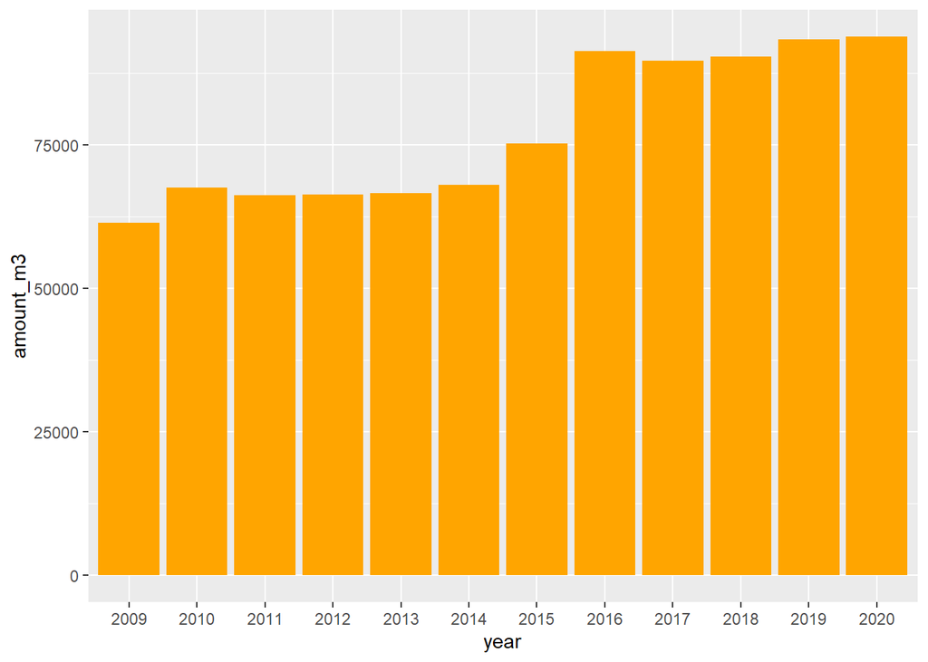

```r
p<-ggplot(data=water.production.tahtali, aes(x=year, y=amount_m3)) +
  geom_bar(stat="identity", fill="orange")

p
```

Histograms of Water Production in Tahtali

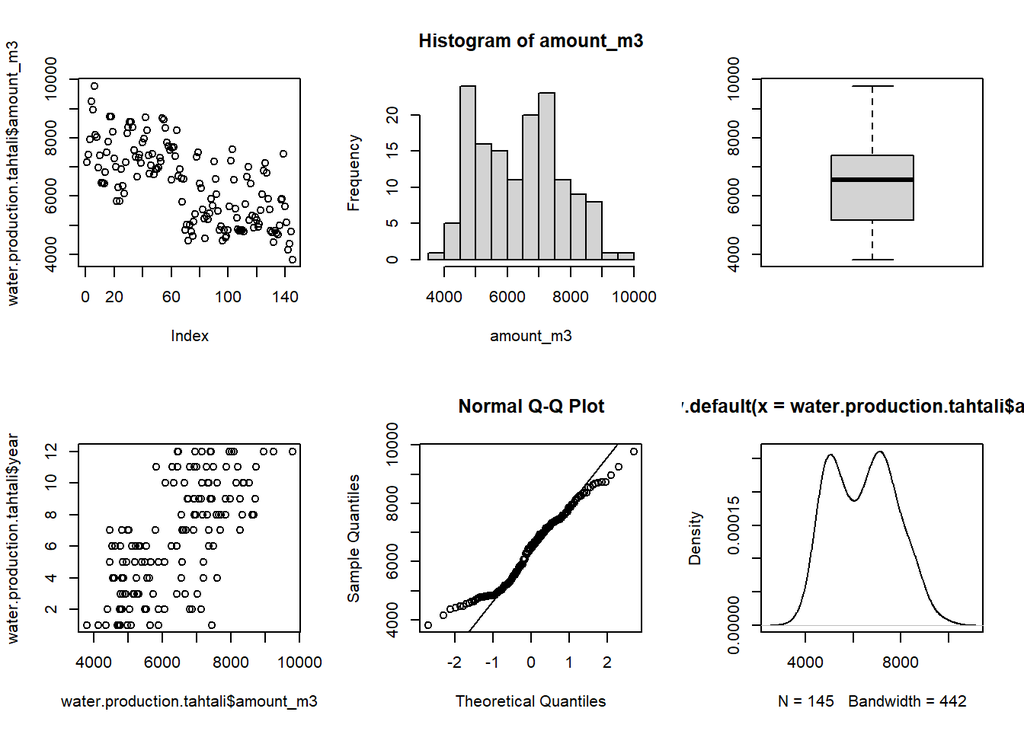

```r
par(mfrow = c(2,3))
plot(water.production.tahtali$amount_m3)
with(water.production.tahtali, hist(amount_m3))
with(water.production.tahtali, boxplot(amount_m3))
plot(water.production.tahtali$amount_m3, water.production.tahtali$year)
qqnorm(water.production.tahtali$amount_m3)
qqline(water.production.tahtali$amount_m3)
plot(density(water.production.tahtali$amount_m3))
```

**Note:** It seems that we have bimodal distribution. It means that there should be different classes. Therefore we’ll divide our data into two groups: *Water Consumpiton Before 2015* and *Water Consumption After 2015* and then we’ll plot again.

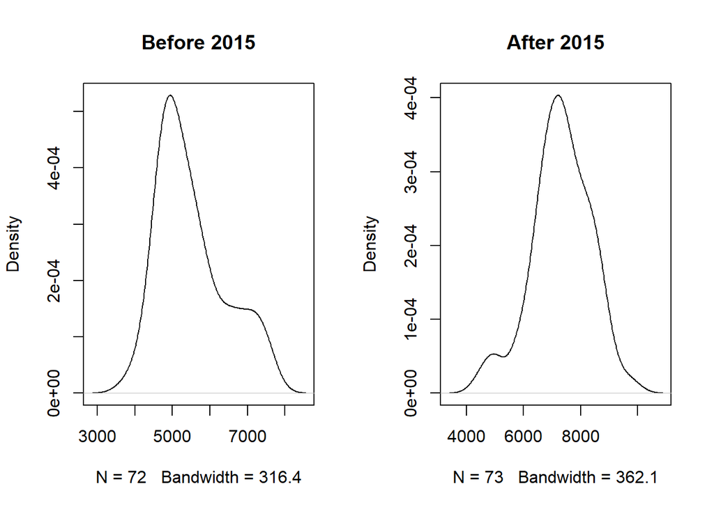

```r
water.production.tahtali$year = as.numeric(as.character(water.production.tahtali$year))
water.production.tahtali$seasons = cut(water.production.tahtali$year,c(2008,2014,2020))
levels(water.production.tahtali$seasons) = c("before_2015","after_2015")

#Divide data into two different classes. before.2015 and after.2015
tahtali.before.2015 =subset(water.production.tahtali, subset = water.production.tahtali$seasons == "before_2015")
tahtali.after.2015 =subset(water.production.tahtali, subset = water.production.tahtali$seasons == "after_2015")


par(mfrow= c(1,2))
plot(density(tahtali.before.2015$amount_m3), main = "Before 2015")
plot(density(tahtali.after.2015$amount_m3), main="After 2015")
```

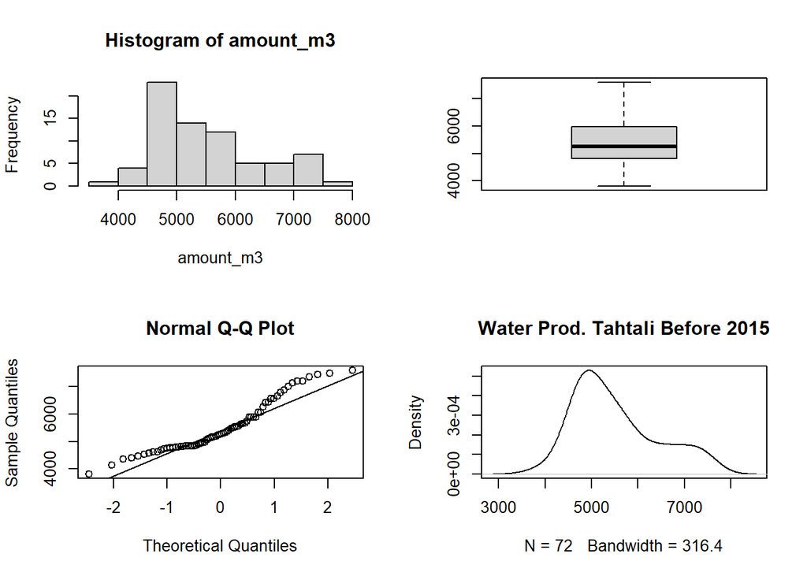

```r
par(mfrow = c(2,2))
with(tahtali.before.2015, hist(amount_m3),main = "Water Prod. Tahtali Before 2015")
with(tahtali.before.2015, boxplot(amount_m3),main = "Water Prod. Tahtali Before 2015")
qqnorm(tahtali.before.2015$amount_m3)
qqline(tahtali.before.2015$amount_m3)
plot(density(tahtali.before.2015$amount_m3),main = "Water Prod. Tahtali Before 2015")
```

```r
shapiro.test(tahtali.before.2015$amount_m3)
```

```
##
##  Shapiro-Wilk normality test
##
## data:  tahtali.before.2015$amount_m3
## W = 0.92553, p-value = 0.0003814
```

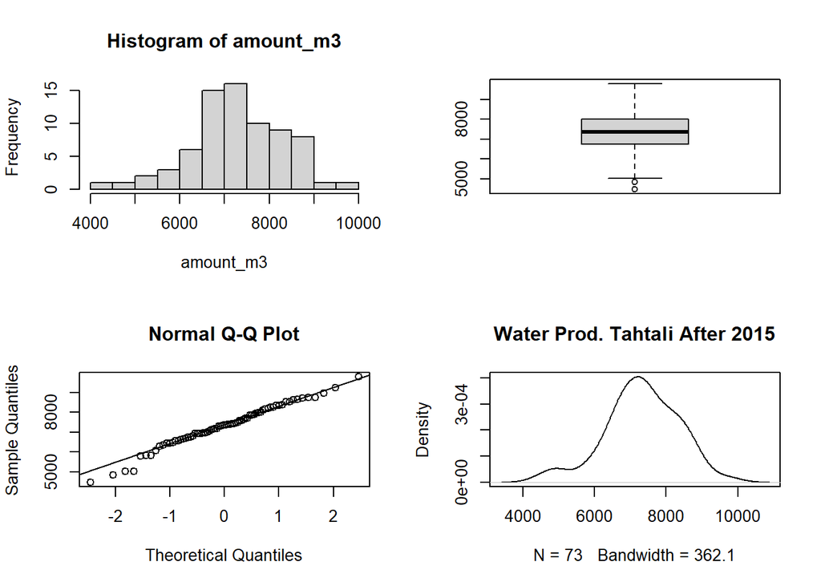

```r
par(mfrow = c(2,2)) # Display plots in a single 2 x 2 figure
with(tahtali.after.2015, hist(amount_m3),main = "Water Prod. Tahtali After 2015")
with(tahtali.after.2015, boxplot(amount_m3),main = "Water Prod. Tahtali After 2015")
qqnorm(tahtali.after.2015$amount_m3)
qqline(tahtali.after.2015$amount_m3)
plot(density(tahtali.after.2015$amount_m3),main = "Water Prod. Tahtali After 2015")
```

```r
shapiro.test(tahtali.after.2015$amount_m3)
```

```
##
##  Shapiro-Wilk normality test
##
## data:  tahtali.after.2015$amount_m3
## W = 0.98236, p-value = 0.3997
```

**Note:** After that point *Water Production in Tahtali After 2015* seems normally distributed by the above plots and also from the Shapiro Test. Our p value > 0.05 and that’s mean we can not reject that data are not significantly different from normal distribution, but *Water Production in Tahtali Before 2015* doesn’t look like normally distributed and we’ll assume that both of them are normally distributed.

### Let’s compare the Confidence Intervals.

- Our confidince coefficient is 0.95 it’s mean that our sample means are appear between Confidince Interval by 95%.
- Confidence Interval of Water Production Before 2015 in Tahtali Baraji

```r
before.2015.CI <- t.test(tahtali.before.2015$amount_m3)$conf.int
before.2015.CI
```

```
## [1] 5291.162 5717.806
## attr(,"conf.level")
## [1] 0.95
```

- Confidence Interval of Water Production After 2015 in Tahtali Baraji.

```r
after.2015.CI <- t.test(tahtali.after.2015$amount_m3)$conf.int
after.2015.CI
```

```
## [1] 7075.987 7557.701
## attr(,"conf.level")
## [1] 0.95
```

**Note:** Confidence intervals suggest that the Water Production between *Before 2015* and *After 2015* are significantly different from each others.

Before going for a t-test let’s check if the variance of two groups are equal with F-test.

```r
res.ftest <- var.test(amount_m3 ~ seasons, data = water.production.tahtali)
res.ftest
```

```
##
##  F test to compare two variances
##
## data:  amount_m3 by seasons
## F = 0.77331, num df = 71, denom df = 72, p-value = 0.2798
## alternative hypothesis: true ratio of variances is not equal to 1
## 95 percent confidence interval:
##  0.4848107 1.2344438
## sample estimates:
## ratio of variances
##          0.7733108
```

```r
paste("p-value of F-test greater than alpha(0.05) that means there is no significant difference between the variances of the two sets. Therefore we can continue with the t-test")
```

```
## [1] "p-value of F-test greater than alpha(0.05) that means there is no significant difference between the variances of the two sets. Therefore we can continue with the t-test"
```

Now let’s test our hypothesis using Welch Two Sample t-test

**Ho:** Mu before_2015 = Mu after_2015 and **H1:** Mu before_2015 != Mu after_2015

```r
tahtali.t.test <- with(water.production.tahtali, t.test(x=amount_m3[seasons=="after_2015"],
                     y=amount_m3[seasons=="before_2015"]))

before.after.2015.diff <- round((tahtali.t.test$estimate[1] - tahtali.t.test$estimate[2]), 1)

# Confidence level as a %
conf.level <- attr(tahtali.t.test$conf.int, "conf.level") * 100
```

**Results**: Our study finds that water productions are on average 1812.4m<sup>3</sup>/10<sup>3</sup> higher After 2015 compared to the Before 2015 (t-statistic 11.23, p=0, 95% CI [1493.3, 2131.4]m<sup>3</sup> / 10<sup>3</sup>)

**Our p-value is less than 0.05(alpha) and also our confidence interval doesn’t include 0. That’s mean Water Production after 2015 and before 2015 are significantly different from each others. And we can reject that Mu before_2015 is equal to Mu after_2015(H0). Also we can conclude that from the Confidence Intervals, Tahtali Baraji is much more productive after 2015.**

Menemen - Çavuşköy Kuyuları and Sarıkız Kuyuları seems to produce almost same. Let’s discover if our hypothesis is statistically true or not.

- First visualize the data and check for the normality.

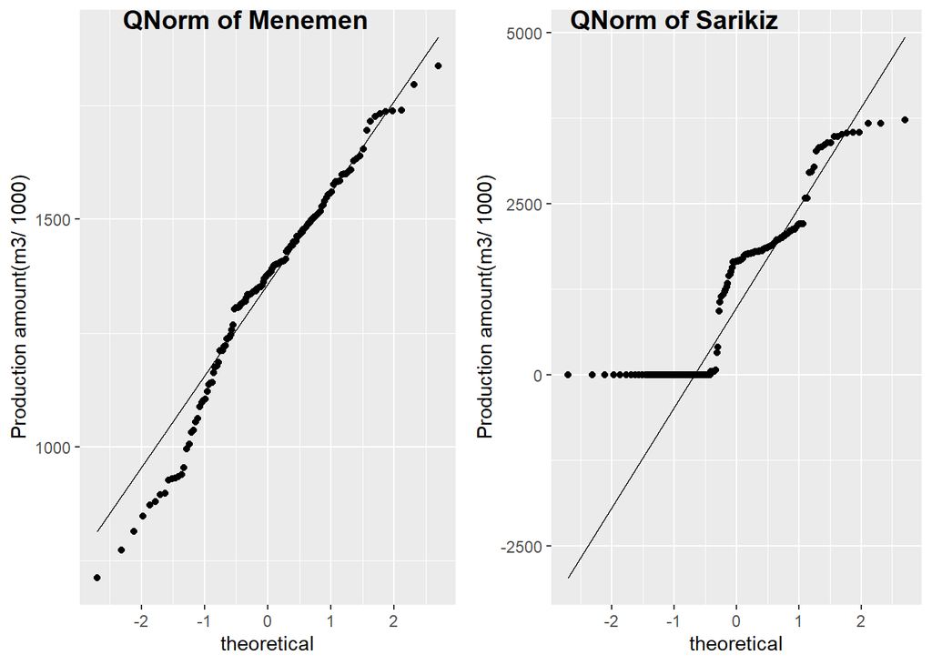

```r
production.menemen = subset(water.production, subset = water.production$source == "Menemen - Çavuşköy Kuyuları")
production.sarikiz = subset(water.production, subset = water.production$source == "Sarıkız Kuyuları")

production.menemen$amount_m3 = production.menemen$amount_m3 / 10**3
production.sarikiz$amount_m3 = production.sarikiz$amount_m3 / 10**3

p1 <- ggplot(production.menemen, aes(sample = amount_m3)) + ylab("Production amount(m3/ 1000)") +
  stat_qq() +
  stat_qq_line()

p2 <- ggplot(production.sarikiz, aes(sample = amount_m3)) + ylab("Production amount(m3/ 1000)") +
  stat_qq() +
  stat_qq_line()



ggarrange(p1, p2, ncol =2, nrow = 1, labels = c( "QNorm of Menemen","QNorm of Sarikiz"))
```

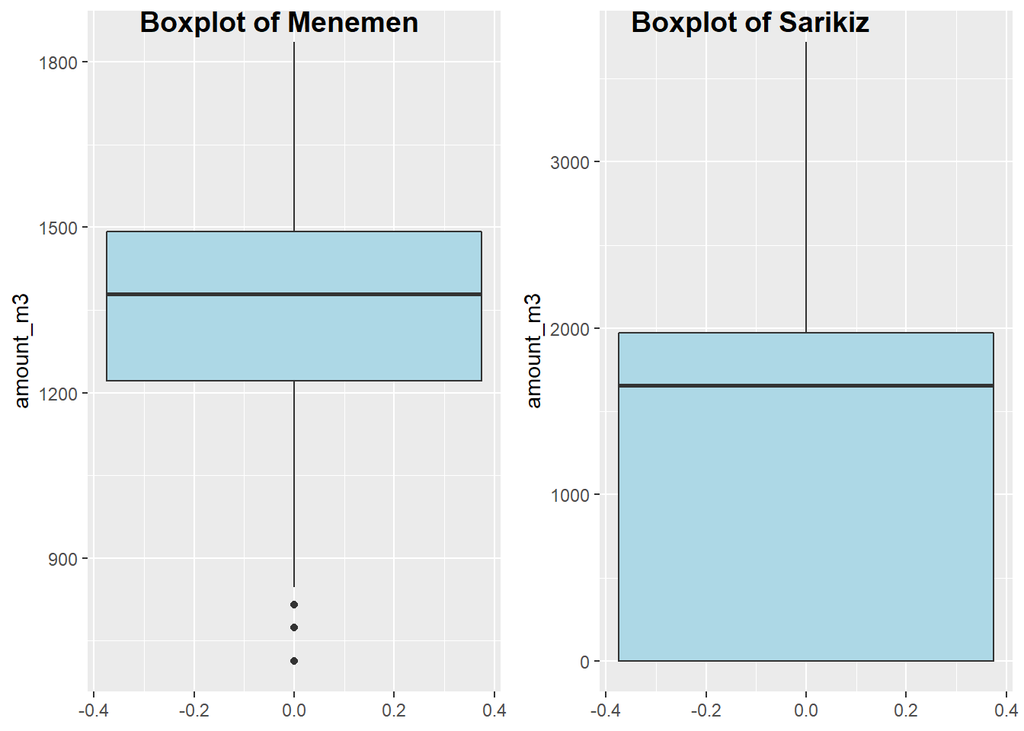

```r
p1 <- ggplot(production.menemen, aes(y = amount_m3))
p1 <- p1 + geom_boxplot(fill=I("lightblue"))

p2 <- ggplot(production.sarikiz, aes(y = amount_m3))
p2 <- p2 + geom_boxplot(fill=I("lightblue"))


ggarrange(p1, p2, ncol =2, nrow = 1, labels = c( "Boxplot of Menemen","Boxplot of Sarikiz"))
```

```r
shapiro.test(production.menemen$amount_m3)
```

```
##
##  Shapiro-Wilk normality test
##
## data:  production.menemen$amount_m3
## W = 0.96884, p-value = 0.002192
```

```r
shapiro.test(production.sarikiz$amount_m3)
```

```
##
##  Shapiro-Wilk normality test
##
## data:  production.sarikiz$amount_m3
## W = 0.85975, p-value = 2.008e-10
```

**Note:** It seems that in Sarikiz data there are lot’s of outliers and missing information. We’ll just take the positive values for amount_m3 and plot the boxplot again.

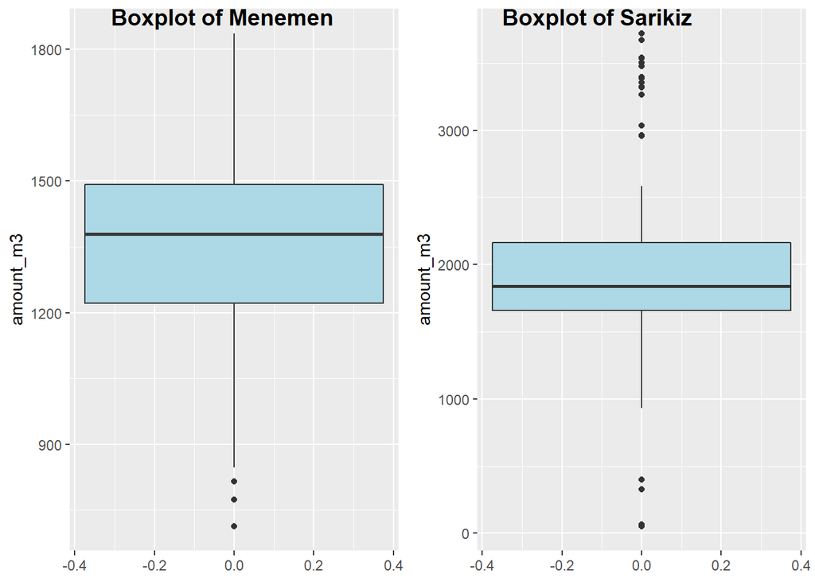

```r
production.sarikiz = subset(production.sarikiz, subset = production.sarikiz$amount_m3 > 0)
p1 <- ggplot(production.menemen, aes(y = amount_m3))
p1 <- p1 + geom_boxplot(fill=I("lightblue"))

p2 <- ggplot(production.sarikiz, aes(y = amount_m3))
p2 <- p2 + geom_boxplot(fill=I("lightblue"))


ggarrange(p1, p2, ncol =2, nrow = 1, labels = c( "Boxplot of Menemen","Boxplot of Sarikiz"))
```

There are still outliers for Menemen and Sarikiz. We’ll remove the outliers and plot the data again. We’ll use the Iner Quartile Range for detecting outliers. And an outlier would be a point below [Q1- (1.5)IQR] or above [Q3+(1.5)IQR].

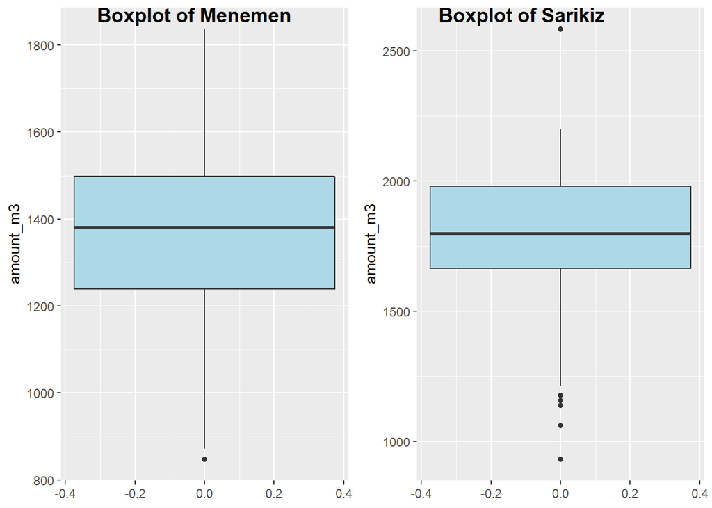

```r
Q.menemen <- quantile(production.menemen$amount_m3, probs=c(.25, .75), na.rm = FALSE)
Q.sarikiz <- quantile(production.sarikiz$amount_m3, probs=c(.25, .75), na.rm = FALSE)

iqr.menemen <- IQR(production.menemen$amount_m3)
iqr.sarikiz <- IQR(production.sarikiz$amount_m3)

low.menemen<- Q.menemen[1]-1.5*iqr.menemen # Lower Range of Menemen

up.sarikiz <-  Q.sarikiz[2]+1.5*iqr.sarikiz # Upper Range of Sarikiz
low.sarikiz<- Q.sarikiz[1]-1.5*iqr.sarikiz # Lower Range of Sarikiz


production.menemen.outlier <- subset(production.menemen, subset = production.menemen$amount_m3 > low.menemen)
production.sarikiz.outlier <- subset(production.sarikiz, subset = production.sarikiz$amount_m3 < up.sarikiz & production.sarikiz$amount_m3 > low.sarikiz)


p1 <- ggplot(production.menemen.outlier, aes(y = amount_m3))
p1 <- p1 + geom_boxplot(fill=I("lightblue"))

p2 <- ggplot(production.sarikiz.outlier, aes(y = amount_m3))
p2 <- p2 + geom_boxplot(fill=I("lightblue"))


ggarrange(p1, p2, ncol =2, nrow = 1, labels = c( "Boxplot of Menemen","Boxplot of Sarikiz"))
```

We almost remove all the outliers and the above boxplot suggests that Menemen Kuyulari produce less water than Sarikiz Kuyulari. Now we can check for normality test.

```r
shapiro.test(production.menemen.outlier$amount_m3)
```

```
##
##  Shapiro-Wilk normality test
##
## data:  production.menemen.outlier$amount_m3
## W = 0.97305, p-value = 0.006617
```

```r
shapiro.test(production.sarikiz.outlier$amount_m3)
```

```
##
##  Shapiro-Wilk normality test
##
## data:  production.sarikiz.outlier$amount_m3
## W = 0.95466, p-value = 0.01195
```

```r
production.menemen.log <- transform(production.menemen.outlier,
            amount_m3 = log(amount_m3))

production.sarikiz.log <- transform(production.sarikiz.outlier,
            amount_m3 = log(amount_m3))

shapiro.test(production.menemen.log$amount_m3)
```

```
##
##  Shapiro-Wilk normality test
##
## data:  production.menemen.log$amount_m3
## W = 0.93969, p-value = 8.605e-06
```

```r
shapiro.test(production.sarikiz.log$amount_m3)
```

```
##
##  Shapiro-Wilk normality test
##
## data:  production.sarikiz.log$amount_m3
## W = 0.90931, p-value = 8.244e-05
```

As we can see after transformation p-values for Shapiro normality test became almost zero and we reject that our data normally distributed. From now on we’ll assume that our data normally distributed.

```r
sarikiz.menemen.t.test <- t.test(x=production.sarikiz.outlier$amount_m3,
                     y=production.sarikiz.outlier$amount_m3, var.equal = TRUE)

cons.sarikiz.menemen.diff <- round((sarikiz.menemen.t.test$estimate[1] - sarikiz.menemen.t.test$estimate[2]), 1)

# Confidence level as a %
conf.level <- attr(sarikiz.menemen.t.test$conf.int, "conf.level") * 100
```

### ANOVA

- Let’s compare the less productive three source and see if the average production of each are equal or not.
- List the production of the sources by descending order.

```r
df1 <- water.production %>%
  group_by(source) %>%
  summarize(total_amount = sum(amount_m3))

df1 <- df1 %>%
  arrange(desc(total_amount))

df1 %>% tbl_df %>% print(n=15)
```

```
## # A tibble: 13 x 2
##    source                            total_amount
##    <fct>                                    <dbl>
##  1 Tahtalı Barajı                       930452445
##  2 Göksu Kuyuları                       575342231
##  3 Halkapınar Kuyuları                  378593273
##  4 Menemen - Çavuşköy Kuyuları          195378337
##  5 Sarıkız Kuyuları                     188932250
##  6 Gördes Barajı                        137755577
##  7 Balçova Barajı                        63903955
##  8 Alaçatı Kutlu Aktaş Barajı            30424481
##  9 Pınarbaşı Kuyuları                    17687851
## 10 Ürkmez Barajı                         14939942
## 11 Güzelhisar Barajı                     14627134
## 12 Ödemiş İçme Suyu Arıtma Tesisleri      9434313
## 13 Buca ve Sarnıç Kuyuları                7697653
```

As we can see from above the less productive three sources are Güzelhisar Barajı, Ödemiş İçme Suyu Arıtma Tesisleri and Buca ve Sarnıç Kuyuları. Now visualize them and see if the data normally distributed or not. Before seperating the groups amount_m3 will be divided by 10<sup>3</sup> for observing the values better.

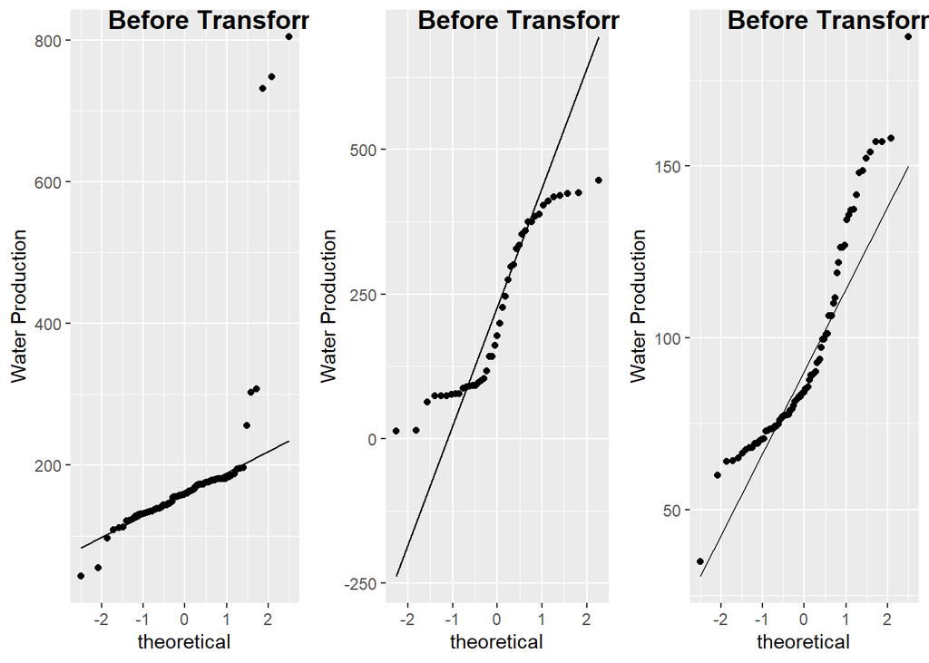

```r
water.production.1 <- water.production
water.production.1$amount_m3 <- (water.production$amount_m3) / 1000

water.cons.guzelhasir= subset(water.production.1, subset = source == "Güzelhisar Barajı" & amount_m3 > 0)
water.cons.odemis = subset(water.production.1, subset = source == "Ödemiş İçme Suyu Arıtma Tesisleri" & amount_m3 > 0)
water.cons.buca.sarnic = subset(water.production.1, subset = source == "Buca ve Sarnıç Kuyuları" & amount_m3 > 0)

p1 <- ggplot(water.cons.guzelhasir, aes(sample = amount_m3)) + ylab("Water Production") +
  stat_qq() +
  stat_qq_line()

p2 <- ggplot(water.cons.odemis, aes(sample = amount_m3)) + ylab("Water Production") +
  stat_qq() +
  stat_qq_line()

p3 <- ggplot(water.cons.buca.sarnic, aes(sample = amount_m3)) + ylab("Water Production") +
  stat_qq() +
  stat_qq_line()

ggarrange(p1, p2, p3, ncol =3, nrow = 1, labels = c( "Before Transform","Before Transform",
                                                 "Before Transform"))
```

```r
shapiro.test(water.cons.guzelhasir$amount_m3)
```

```
##
##  Shapiro-Wilk normality test
##
## data:  water.cons.guzelhasir$amount_m3
## W = 0.4452, p-value = 6.075e-16
```

```r
shapiro.test(water.cons.odemis$amount_m3)
```

```
##
##  Shapiro-Wilk normality test
##
## data:  water.cons.odemis$amount_m3
## W = 0.87554, p-value = 0.0002455
```

```r
shapiro.test(water.cons.buca.sarnic$amount_m3)
```

```
##
##  Shapiro-Wilk normality test
##
## data:  water.cons.buca.sarnic$amount_m3
## W = 0.88857, p-value = 3.676e-06
```

From above plots and the Shapiro test we can conclude that three set of data are not normally distributed. Let’s transform them and check the normality again.

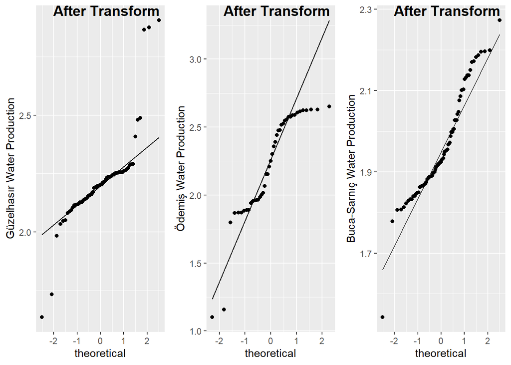

```r
water.cons.guzelhasir.log <- transform(water.cons.guzelhasir,
            amount_m3 = log10(amount_m3))
water.cons.odemis.log <- transform(water.cons.odemis,
            amount_m3 = log10(amount_m3))
water.cons.buca.sarnic.log <- transform(water.cons.buca.sarnic,
            amount_m3 = log10(amount_m3))

p1 <- ggplot(water.cons.guzelhasir.log, aes(sample = amount_m3)) + ylab("Güzelhasır Water Production") +
  stat_qq() +
  stat_qq_line()

p2 <- ggplot(water.cons.odemis.log, aes(sample = amount_m3)) + ylab("Ödemiş Water Production") +
  stat_qq() +
  stat_qq_line()

p3 <- ggplot(water.cons.buca.sarnic.log, aes(sample = amount_m3)) + ylab("Buca-Sarnıç Water Production") +
  stat_qq() +
  stat_qq_line()

ggarrange(p1, p2, p3, ncol =3, nrow = 1, labels = c( "After Transform","After Transform",
                                                 "After Transform"))
```

```r
shapiro.test(water.cons.guzelhasir.log$amount_m3)
```

```
##
##  Shapiro-Wilk normality test
##
## data:  water.cons.guzelhasir.log$amount_m3
## W = 0.73836, p-value = 1.043e-10
```

```r
shapiro.test(water.cons.odemis.log$amount_m3)
```

```
##
##  Shapiro-Wilk normality test
##
## data:  water.cons.odemis.log$amount_m3
## W = 0.87129, p-value = 0.0001879
```

```r
shapiro.test(water.cons.buca.sarnic.log$amount_m3)
```

```
##
##  Shapiro-Wilk normality test
##
## data:  water.cons.buca.sarnic.log$amount_m3
## W = 0.93909, p-value = 0.0007916
```

After log transformassion the data still not normal and from now on we’ll assume that the data normally distributed. Now let’s compute the One-way ANOVA test.

**H0:** Mu cons.guzelhasir = Mu cons.odemis = Mu cons.buca.sarnic, **H1:** At least one differs.

```r
water.production.1 <- subset(water.production.1, subset =  (source == "Güzelhisar Barajı" | source == "Buca ve Sarnıç Kuyuları"
                                                                     | source == "Ödemiş İçme Suyu Arıtma Tesisleri") & amount_m3 > 0)

water.production.1.log <- transform(water.production.1,
            amount_m3 = log10(amount_m3))

# Compute the analysis of variance
res.aov <- aov(amount_m3 ~ source, data = water.production.1.log)
# Summary of the analysis
summary(res.aov)
```

```
##              Df Sum Sq Mean Sq F value   Pr(>F)
## source        2  3.144  1.5719   32.32 6.63e-13 ***
## Residuals   202  9.824  0.0486
## ---
## Signif. codes:  0 '***' 0.001 '**' 0.01 '*' 0.05 '.' 0.1 ' ' 1
```

**Result:** The p-value obtained from ANOVA is almost 0 and less than alpha(0.05) therefore we reject that the average water production of three sources is the same. In other words, there is strong evidence that at least one differs.

- Let’s compute the Tukey Test and see which are differs.

```r
TukeyHSD(res.aov)
```

```
##   Tukey multiple comparisons of means
##     95% family-wise confidence level
##
## Fit: aov(formula = amount_m3 ~ source, data = water.production.1.log)
##
## $source
##                                                                  diff
## Güzelhisar Barajı-Buca ve Sarnıç Kuyuları                 0.252092586
## Ödemiş İçme Suyu Arıtma Tesisleri-Buca ve Sarnıç Kuyuları 0.255566942
## Ödemiş İçme Suyu Arıtma Tesisleri-Güzelhisar Barajı       0.003474356
##                                                                   lwr       upr
## Güzelhisar Barajı-Buca ve Sarnıç Kuyuları                  0.17027190 0.3339133
## Ödemiş İçme Suyu Arıtma Tesisleri-Buca ve Sarnıç Kuyuları  0.15731871 0.3538152
## Ödemiş İçme Suyu Arıtma Tesisleri-Güzelhisar Barajı       -0.09477387 0.1017226
##                                                               p adj
## Güzelhisar Barajı-Buca ve Sarnıç Kuyuları                 0.0000000
## Ödemiş İçme Suyu Arıtma Tesisleri-Buca ve Sarnıç Kuyuları 0.0000000
## Ödemiş İçme Suyu Arıtma Tesisleri-Güzelhisar Barajı       0.9961638
```